# Plausibility

Andrew Perfors

The goal of this is to determine whether our approach is plausible. What we do is for each experiment, take the inferred parameters ($\beta$ and $\gamma$) and priors for each person, and use those to generate posteriors. Then give the model the priors and generated posteriors and see if the parameters it identifies are the same as the ones used to generate the posteriors.

## Experiment 1

The first step is to generate new posteriors for each person given the $\beta$ and $\gamma$ parameters we inferred. We consider the two ones in the Mᴀɪɴ experiment, with either Five or Unlimited chips.

Then, for person we want to now infer $\beta$ and $\gamma$ based on their prior and generated posterior.

Now we want to see the accuracy of these things.

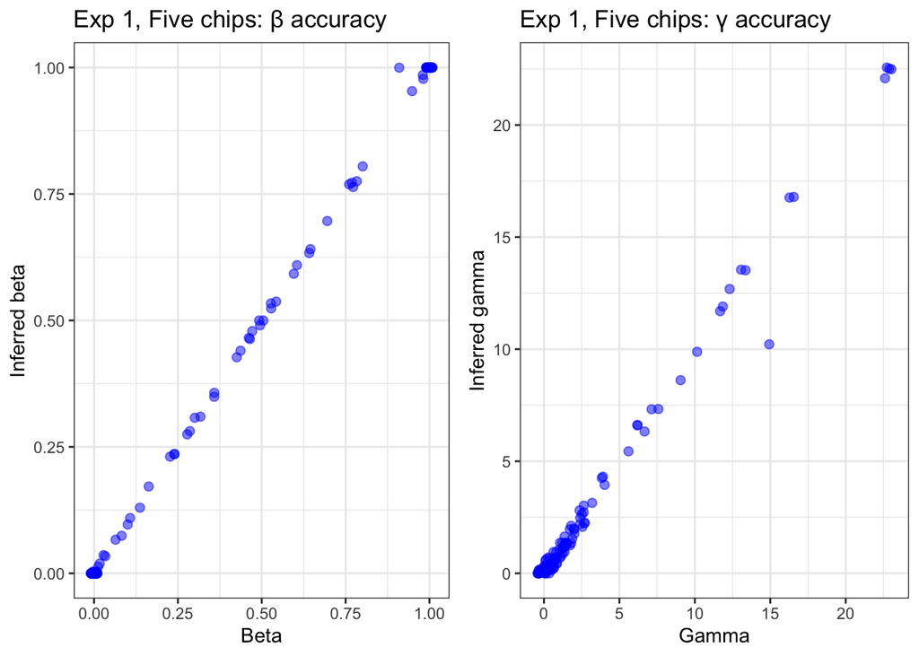

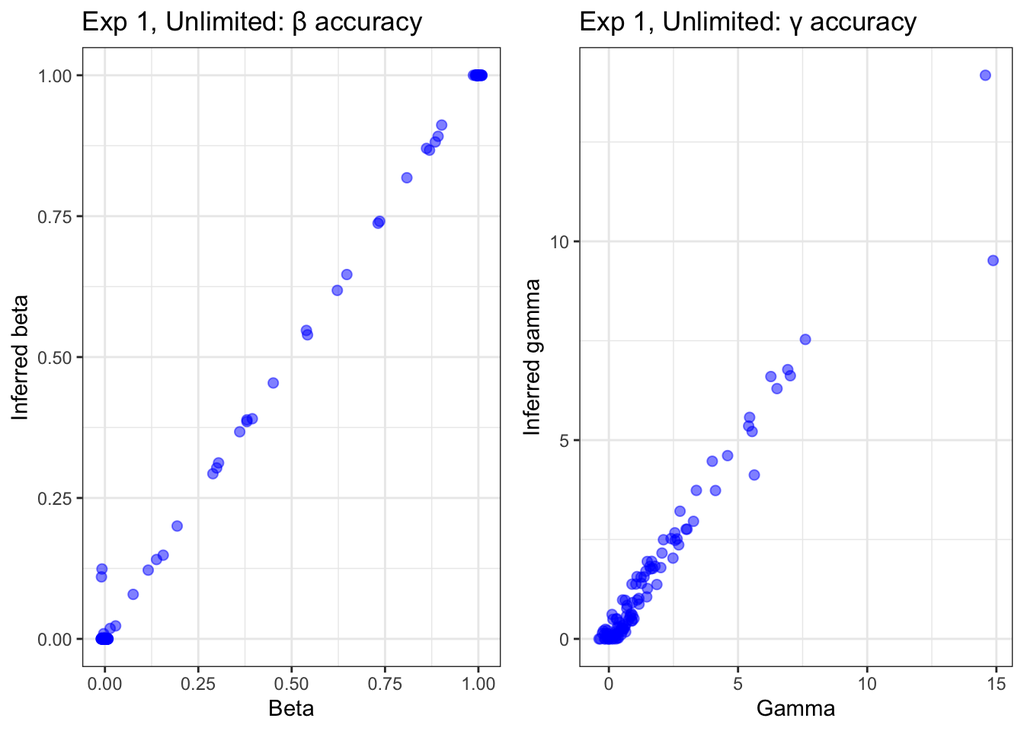

For Five chips, 100% of the inferred beta were less than 0.1 off the original $\beta$ (participant ids were ). The correlation of $\beta$ to inferred $\beta$ was r=0.99974, p=0.

Also, 95.3% of the inferred $\gamma$ were less than 0.1 off (participant ids were 18, 218, 369, 397, 81). The correlation of $\gamma$ to inferred $\gamma$ was r=0.99711, p=0.

For Unlimited chips, 98.1% of the inferred beta were less than 0.1 off the original $\beta$ (participant ids were 31, 397). The correlation of $\beta$ to inferred $\beta$ was r=0.99931, p=0.

Also, 98.1% of the inferred $\gamma$ were less than 0.1 off (participant ids were 31, 397). The correlation of $\gamma$ to inferred $\gamma$ was r=0.97807, p=0.

## Experiment 2

The first step is to generate new posteriors for each person given the $\beta$ and $\gamma$ parameters we inferred. There were two conditions, Pᴇᴀᴋᴇᴅ and Uɴɪғᴏʀᴍ

Then, for each person we want to now infer $\beta$ and $\gamma$ based on their prior and generated posterior. (For the Uniform condition we only infer $\gamma$).

Now we want to see the accuracy of these things.

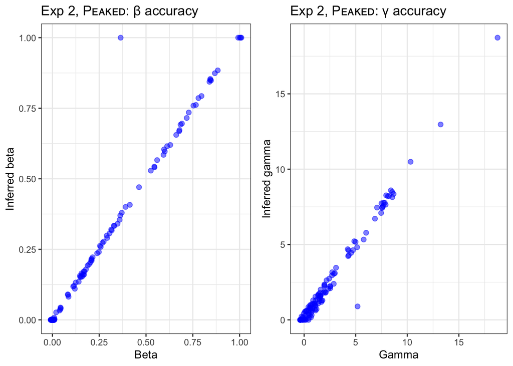

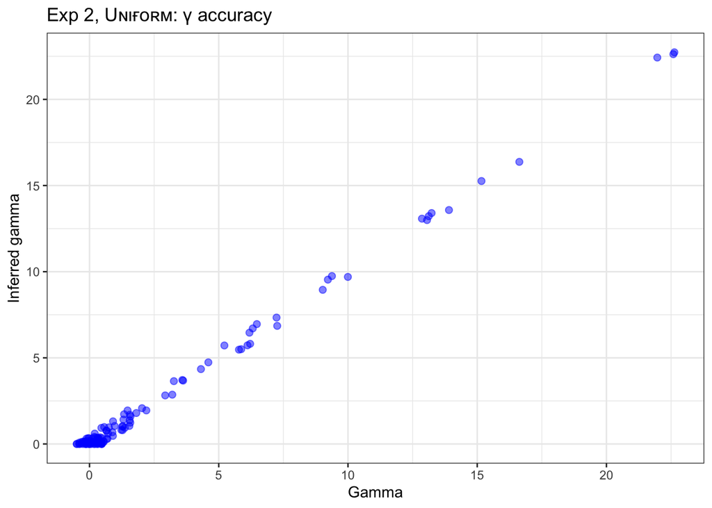

For Pᴇᴀᴋᴇᴅ, 99.2% of the inferred beta were less than 0.1 off the original $\beta$ (participant ids were 232). The correlation of $\beta$ to inferred $\beta$ was r=0.98258, p=0.

Also, 99.2% of the inferred $\gamma$ were less than 0.1 off (participant ids were 232). The correlation of $\gamma$ to inferred $\gamma$ was r=0.99181, p=0.

For Uɴɪғᴏʀᴍ, 100% of the inferred gamma were less than 0.1 off the original gamma (participant ids were ). The correlation of $\gamma$ to inferred $\gamma$ was r=1, p=0.

## Experiment 3

The first step is to generate new posteriors for each person given the $\beta$ and $\gamma$ parameters we inferred. There were two conditions, Esᴛɪᴍᴀᴛᴇᴅ and Gɪᴠᴇɴ

Then, for each person we want to now infer $\beta$ and $\gamma$ based on their prior and generated posterior.

Now we want to see the accuracy of these things.

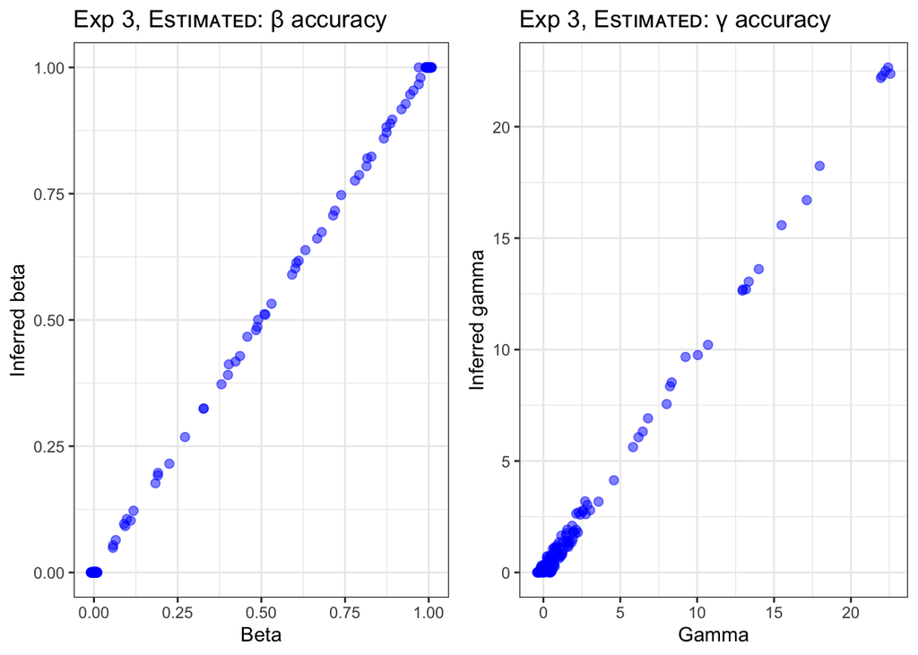

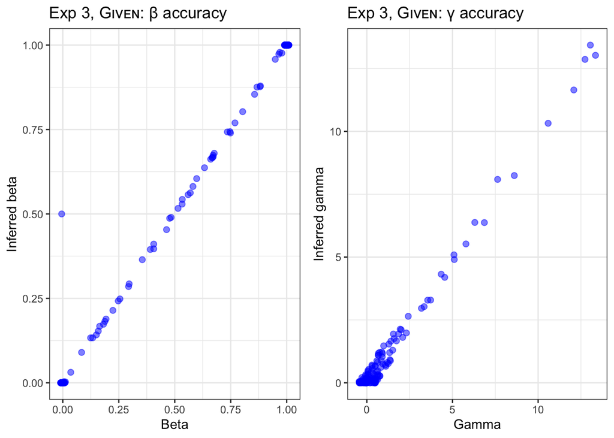

For Esᴛɪᴍᴀᴛᴇᴅ, 100% of the inferred beta were less than 0.1 off the original $\beta$ (participant ids were ). The correlation of $\beta$ to inferred $\beta$ was r=0.99998, p=0.

Also, 97.7% of the inferred $\gamma$ were less than 0.1 off (participant ids were 211, 282, 81). The correlation of $\gamma$ to inferred $\gamma$ was r=1, p=0.

For Gɪᴠᴇɴ, 99.2% of the inferred beta were less than 0.1 off the original $\beta$ (participant ids were 272). The correlation of $\beta$ to inferred $\beta$ was r=0.9948, p=0.